# HW 6: z-tests, t-tests, and effect sizes

# Part C: Do it yourself!

1.1. An outbreak of Salmonella-related illness was attributed to ice cream produced at a certain factory. Scientists measured the level of Salmonella in 9 randomly sampled batches of ice cream. The levels (in MPN/g) were:

- 0.593 0.142 0.329 0.691 0.231 0.793 0.519 0.392 0.418

```r
Salmonella <- c(0.593, 0.142, 0.329, 0.691, 0.231, 0.793, 0.519, 0.392, 0.418)
```

1.2. **QUESTION:** Test whether a normal distribution is a reasonable assumption for those data. Test with alpha = .05. You can look at a histogram and qqplots too if you want.

*ANSWER:*

```r
shapiro.test(Salmonella) # or lilliefors test
```

```
##
##  Shapiro-Wilk normality test
##
## data:  Salmonella
## W = 0.98, p-value = 1
```

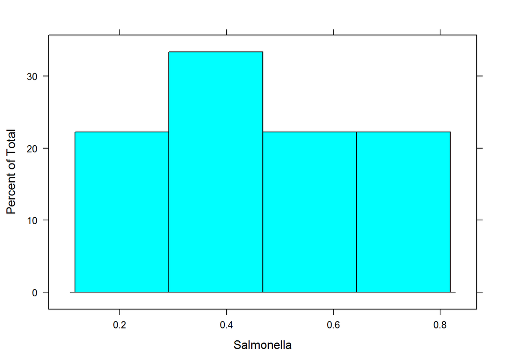

```r
lattice::histogram(~Salmonella)
```

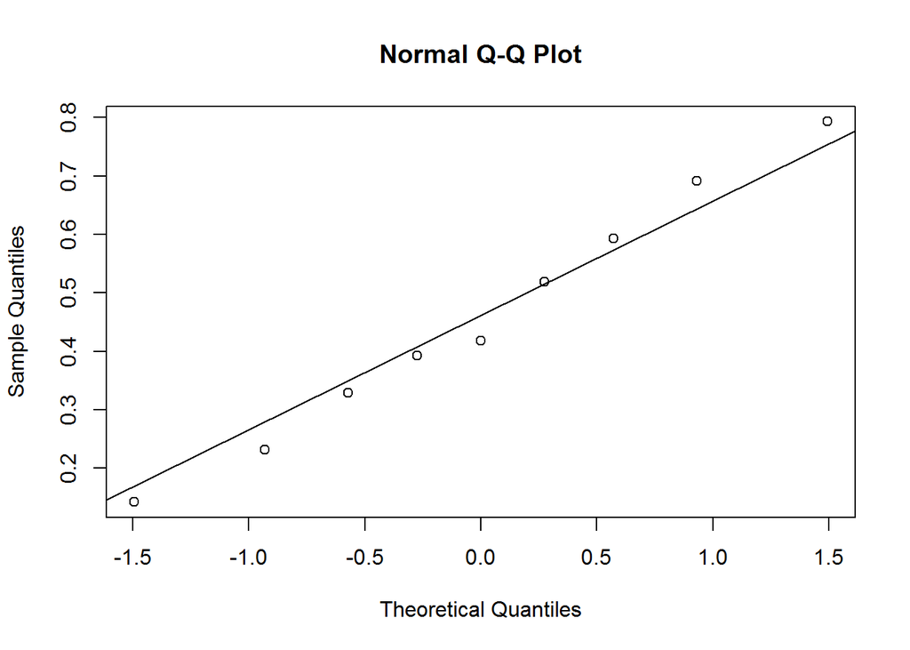

```r
qqnorm(Salmonella); qqline(Salmonella)
```

1.3. **QUESTION:** Is there evidence that the factory has a mean level of Salmonella in the ice cream that differs from 0.3 MPN/g? Note: The variable is not in a data frame, so you cannot use the `with` function unless you make the data into a data frame. Use alpha .05

*ANSWER:*

```r
t.test(Salmonella, mu = .3)
```

```
##
##  One Sample t-test
##
## data:  Salmonella
## t = 2.2, df = 8, p-value = 0.06
## alternative hypothesis: true mean is not equal to 0.3
## 95 percent confidence interval:
##  0.2928 0.6201
## sample estimates:
## mean of x
##    0.4564
```

1.4. **QUESTION:** What do you conclude based on your test output? Be clear in your answer by making sure to explain the nature of the outcome.

*ANSWER:* The distribution does not deviate from that of a normal distribution, *S-W* = .98, *p* > .05; the assumption is met. The salmonella at the factory is numerically higher (.46 MPN/g) than .3 MPN/g, but is not statistically different from that value, *t*(8) = 2.2, *p* > .05. The confidence interval also shows that the true mean for the factory may be below .3 MPN/g. The factory, however, should watch those levels because they are potentially high.

### DONE!

Upload your knit HTML file to Sakai’s dropbox. Make sure to include your name(s).